# Homework 6: Gaslighting Report (Pro)

Isabel Leiva

February 2026

# Instructions

1. State a hypothesis about the gaslighting dataset
2. Develop your processing pipeline and justify steps, etc.
3. Analyze your data, report relevant statistics and visualization(s)
4. State your conclusions

# Hypothesis

Individuals who endorsed gaslighting tell stories that are significantly higher in anger and negative valence, and lower on trust compared to individuals who don’t endorse gaslighting.

## Loading sentiment database and selecting variables

```r
load(url("https://github.com/Reilly-ConceptsCognitionLab/reillylab_publicdata/blob/main/lookup_Jul25.rda?raw=true"))
lookup_db <- lookup_Jul25 #renaming dataframe
colnames(lookup_db)
```

```
##  [1] "word"                    "emo_anger"
##  [3] "emo_anger_rescale"       "emo_anxiety"
##  [5] "emo_anxiety_rescale"     "emo_arousal_b24"
##  [7] "emo_arousal_b24_rescale" "emo_boredom"
##  [9] "emo_boredom_rescale"     "emo_confusion"
## [11] "emo_confusion_rescale"   "emo_excitement"
## [13] "emo_excitement_rescale"  "emo_guilt"
## [15] "emo_guilt_rescale"       "emo_happiness"
## [17] "emo_happiness_rescale"   "emo_intensity"
## [19] "emo_intensity_recale"    "emo_sadness"
## [21] "emo_sadness_rescale"     "emo_trust"
## [23] "emo_trust_rescale"       "emo_valence_b24"
## [25] "emo_valence_b24_rescale" "lex_AoA"
## [27] "lex_AoA_rescale"         "lex_freqlg10"
## [29] "lex_freqlg10_rescale"    "lex_n_morphemes"
## [31] "lex_n_senses"            "lex_n_senses_rescale"
## [33] "phon_n_lett"             "phon_nsyll"
## [35] "sem_auditory"            "sem_auditory_rescale"
## [37] "sem_cnc_b24"             "sem_cnc_b24_rescale"
## [39] "sem_cnc_v2013"           "sem_cnc_v2013_rescale"
## [41] "sem_diversity"           "sem_diversity_rescale"
## [43] "sem_neighbors"           "sem_neighbors_rescale"
## [45] "sem_visual"              "sem_visual_rescale"
```

```r
lookup_small <- lookup_db %>% dplyr::select(word, emo_anger_rescale, emo_valence_b24_rescale, emo_trust_rescale) #creating database that suites hypotheses being tested
lookup_small[1:20,] #printing the first 20 lines of the df
```

| word | emo_anger_rescale | emo_valence_b24_rescale | emo_trust_rescale |
| --- | --- | --- | --- |
| a | 2.58 | 4.51 | 2.75 |
| aa | 2.29 | 4.49 | 3.20 |
| aaa | 1.87 | NA | 3.47 |
| aaaa | 1.74 | NA | 3.23 |
| aaaaa | 2.29 | NA | 2.76 |
| aaaaaaaaah | 1.94 | NA | 2.71 |
| aaaaaaaah | 2.62 | NA | 2.11 |
| aaaaaaah | 2.81 | 4.60 | 2.35 |
| aaaaaah | 2.20 | NA | 2.48 |
| aaaaah | 2.03 | NA | 1.91 |
| aaaaahhh | 2.48 | NA | 1.92 |
| aaaaahhhh | 2.50 | NA | 1.87 |
| aaaaahhhhh | 2.72 | NA | 1.75 |
| aaaaargh | 2.40 | NA | 1.93 |
| aaaagh | 2.85 | NA | 1.87 |
| aaaah | 2.36 | 5.57 | 2.15 |
| aaaahh | 2.33 | NA | 1.82 |
| aaaahhh | 1.99 | NA | 1.93 |
| aaaahhhh | 2.31 | NA | 2.32 |
| aaaargh | 3.08 | NA | 1.52 |

## Load and Inspect Gaslighting Corpus

```r
# Load gaslight corpus
load(url("https://github.com/Reilly-ConceptsCognitionLab/reillylab_publicdata/blob/main/gaslight.rda?raw=true"))
str(gaslight) #identifying variable types
```

```
## 'data.frame':    1034 obs. of  7 variables:
##  $ X                  : int  1 2 3 4 5 6 7 8 9 10 ...
##  $ ID                 : int  814 2130 2143 2145 2146 2151 2154 2163 2171 2174 ...
##  $ gd_adult_definition: chr  "Trying to convince someone to feel like it is their fault they are feeling negative emotions or that it happene"| __truncated__ "gaslighting is when someone tries to make you believe something you know as something else try to sound like a "| __truncated__ "to me it …
##  $ gd_adult_story     : chr  "The student is harassed by a customer. She says stuff back to the customer which makes the customer more angry "| __truncated__ "the student worker takes an order and makes a coffee that was ordered however the customer didn't like the coff"| __truncated__ "The super…
##  $ Ever_Gaslit        : chr  "No" "No" "No" "No" ...
##  $ Gender             : chr  "Female" "Female" "Female" "Male" ...
##  $ Age                : int  19 NA 18 24 21 18 21 21 23 20 ...
```

```r
#making the following variables factors
gaslight$Gender <- as.factor(gaslight$Gender)
gaslight$ID <-  as.factor(gaslight$ID)
gaslight$Ever_Gaslit <- as.factor(gaslight$Ever_Gaslit)
#confirming variables are now factors
str(gaslight$Gender) %>%
str(gaslight$ID) %>%
str(gaslight$Ever_Gaslit)
```

```
##  Factor w/ 3 levels "","Female","Male": 2 2 2 3 2 2 2 2 3 2 ...
##  NULL
##  NULL
```

# Cleaning genie

Based HEAVILY on Jamie’s but with more annotation because mine missed a few and this catches them “stray dogs”

```r
cleaning_genie <- function(dat, wordcol, omit_stops = TRUE, lemmatize = TRUE) {
  # Input validation
  #telling R what column in your dataframe is the text in quotes 'wordcol', this error message checks
  if (!wordcol %in% names(dat)) {
    stop(paste("Column", wordcol, "not found in dataframe"))
  }
#load stopword and replacement lists from github
load(url("https://github.com/Reilly-ConceptsCognitionLab/reillylab_publicdata/blob/main/Temple_stops25.rda?raw=true"))
load(url("https://github.com/Reilly-ConceptsCognitionLab/reillylab_publicdata/blob/main/replacements_25.rda?raw=true"))

# Creating a working df and standardizing
  dat_prep <- dat %>% #creating a working df called "dat prep"
    dplyr::mutate(id_row_orig = factor(seq_len(nrow(dat))), # creating a new row that tracks id number (starting from 1)
      text_initialsplit = tryCatch(stringi::stri_enc_toutf8(as.character(.[[wordcol]]), #creating new row that standardizes text as UTF8
                                 is_unknown_8bit = TRUE,
                                 validate = TRUE), error = function(e) stringi::stri_encode(as.character(.[[wordcol]]), to = "UTF-8")
      ) %>% tolower()) #makes all text lower case

  # Standardize apostrophes in original text
  dat_prep <- dat_prep %>% dplyr::mutate(text_initialsplit = ifelse(
        is.na(text_initialsplit), NA_character_, stringi::stri_replace_all_regex(
          text_initialsplit,
          "[\u2018\u2019\u02BC\u201B\uFF07\u0092\u0091\u0060\u00B4\u2032\u2035]",
          "'"
        )
      )
    )

  # Perform initial split into words (retains contractions)
  dat_prep <- dat_prep %>% tidyr::separate_rows(text_initialsplit, sep = "[[:space:]]+") %>%
    dplyr::mutate(
      text_initialsplit = ifelse(
        is.na(text_initialsplit) | stringi::stri_isempty(text_initialsplit),
        NA_character_,
        text_initialsplit
      )
    ) %>%
    # Remove original column
    dplyr::select(-all_of(wordcol))

  # Creating clean column (called "word_clean") with actual cleaned text
  dat_prep <- dat_prep %>%
    dplyr::mutate(
      word_clean = text_initialsplit,
      # Remove non-alphabetic characters except apostrophes
      word_clean = ifelse(
        is.na(word_clean),
        NA_character_,
        stringi::stri_replace_all_regex(word_clean, "[^a-zA-Z']", " ")
      ),
      # Remove whitespace
      word_clean = ifelse(
        is.na(word_clean),
        NA_character_,
        stringr::str_squish(word_clean)
      ),
      word_clean = ifelse(
        is.na(word_clean),
        NA_character_,
        stringi::stri_replace_all_regex(word_clean, "[^a-z']", "")
      ),
      word_clean = ifelse(
        is.na(word_clean),
        NA_character_,
        stringi::stri_replace_all_regex(word_clean, "[^[:alnum:]']", "")
      )
    )

#Replace words function - this finds contractions and replaces them with their expanded forms from a lookup database.
 replace_words <- function(word_clean, replacement_df) {
 for (i in seq_len(nrow(replacement_df))) {
   text_vector <- gsub(
     pattern = replacement_df$word[i],
     replacement = replacement_df$replacement[i],
     x = word_clean, ignore.case = TRUE)
 }
 return(word_clean)
 }

 #run replace words function on dat_prep
dat_prep <- replace_words(dat_prep, replacement_df = replacements_25)

  # Perform additional splitting after replacements (keeping NAs)
  dat_prep <- dat_prep %>%
    tidyr::separate_rows(word_clean, sep = "[[:space:]]+", convert = TRUE) %>%
    dplyr::mutate(
      word_clean = ifelse(
        is.na(word_clean) | stringi::stri_isempty(word_clean),
        NA_character_,
        word_clean
      ),
      id_row_postsplit = seq_len(dplyr::n())
    )

  # Lemmatization if requested (only for non-NA values)
  if (lemmatize) {
    dat_prep <- dat_prep %>%
      dplyr::mutate(
        word_clean = ifelse(
          is.na(word_clean),
          NA_character_,
          textstem::lemmatize_strings(word_clean)
        )
      )
  }

  # Stopword removal if requested (now keeps NAs)
  if (omit_stops) {
    stopwords <- tolower(Temple_stops25$word)
    dat_prep <- dat_prep %>%
      dplyr::mutate(
        is_stopword = ifelse(
          is.na(word_clean),
          NA,
          word_clean %in% stopwords
        ),
        word_clean = ifelse(is_stopword, NA_character_, word_clean)
      ) %>%
      dplyr::select(-is_stopword)  # Remove the is_stopword column
  }

  return(dat_prep)
}
```

## Deploy Genie

It does not like knitting the genie. Worked around it by saving as a CSV and re-reading it in.

```r
gaslight_analysis <- gaslight %>% dplyr::select(ID, Ever_Gaslit, gd_adult_story)

gaslight_clean <- cleaning_genie(gaslight_analysis, 'gd_adult_story')
write.csv(gaslight_clean, file = "gaslight_clean.csv")
```

# Analysis

## Joining analysis dataframes

```r
gaslight_clean <- read.csv("gaslight_clean.csv")
gaslight_analysis <- gaslight_clean %>% dplyr::left_join(lookup_small, by = c("word_clean" = "word")) #joining gaslighting stories with the sentiment word ratings

gaslight_analysis[1:20,] #printing the first 20 lines of the df
```

| X | ID | Ever_Gaslit | id_row_orig | text_initialsplit | word_clean | id_row_postsplit | emo_anger_rescale | emo_valence_b24_rescale | emo_trust_rescale |
| --- | --- | --- | --- | --- | --- | --- | --- | --- | --- |
| 1 | 814 | No | 1 | the | NA | 1 | NA | NA | NA |
| 2 | 814 | No | 1 | student | student | 2 | 2.21 | 6.01 | 2.51 |
| 3 | 814 | No | 1 | is | NA | 3 | NA | NA | NA |
| 4 | 814 | No | 1 | harassed | harass | 4 | 4.39 | 0.04 | 1.16 |
| 5 | 814 | No | 1 | by | NA | 5 | NA | NA | NA |
| 6 | 814 | No | 1 | a | NA | 6 | NA | NA | NA |
| 7 | 814 | No | 1 | customer. | customer | 7 | 2.47 | 4.81 | 3.77 |
| 8 | 814 | No | 1 | she | NA | 8 | NA | NA | NA |
| 9 | 814 | No | 1 | says | say | 9 | 2.15 | 4.53 | 3.10 |
| 10 | 814 | No | 1 | stuff | stuff | 10 | 2.59 | 4.52 | 2.50 |
| 11 | 814 | No | 1 | back | back | 11 | 2.53 | 4.52 | 2.50 |
| 12 | 814 | No | 1 | to | NA | 12 | NA | NA | NA |
| 13 | 814 | No | 1 | the | NA | 13 | NA | NA | NA |
| 14 | 814 | No | 1 | customer | customer | 14 | 2.47 | 4.81 | 3.77 |
| 15 | 814 | No | 1 | which | NA | 15 | NA | NA | NA |
| 16 | 814 | No | 1 | makes | make | 16 | 1.48 | 4.53 | 3.77 |
| 17 | 814 | No | 1 | the | NA | 17 | NA | NA | NA |
| 18 | 814 | No | 1 | customer | customer | 18 | 2.47 | 4.81 | 3.77 |
| 19 | 814 | No | 1 | more | much | 19 | 2.03 | 4.52 | 2.91 |
| 20 | 814 | No | 1 | angry | angry | 20 | 7.41 | 1.02 | 0.74 |

## LMs!

```r
#running lms to test hypotheses
gaslight_anger <- lm(emo_anger_rescale ~ Ever_Gaslit, data = gaslight_analysis) #anger lmer (not sig)
summary(gaslight_anger)
```

```
##
## Call:
## lm(formula = emo_anger_rescale ~ Ever_Gaslit, data = gaslight_analysis)
##
## Residuals:
##     Min      1Q  Median      3Q     Max
## -2.2158 -0.3366 -0.0408  0.3766  6.1527
##
## Coefficients:
##                Estimate Std. Error t value Pr(>|t|)
## (Intercept)    2.337619   0.007718 302.893   <2e-16 ***
## Ever_GaslitYes 0.002458   0.008687   0.283    0.777
## ---
## Signif. codes:  0 '***' 0.001 '**' 0.01 '*' 0.05 '.' 0.1 ' ' 1
##
## Residual standard error: 0.7388 on 43483 degrees of freedom
##   (41785 observations deleted due to missingness)
## Multiple R-squared:  1.842e-06,  Adjusted R-squared:  -2.116e-05
## F-statistic: 0.08008 on 1 and 43483 DF,  p-value: 0.7772
```

```r
gaslight_val <- lm(emo_valence_b24_rescale ~ Ever_Gaslit, data = gaslight_analysis) #valence lmer (not sig)
summary(gaslight_val)
```

```
##
## Call:
## lm(formula = emo_valence_b24_rescale ~ Ever_Gaslit, data = gaslight_analysis)
##
## Residuals:
##     Min      1Q  Median      3Q     Max
## -4.6407 -0.1575 -0.1463  0.1451  4.3279
##
## Coefficients:
##                Estimate Std. Error t value Pr(>|t|)
## (Intercept)    4.672058   0.011783  396.52   <2e-16 ***
## Ever_GaslitYes 0.002259   0.013265    0.17    0.865
## ---
## Signif. codes:  0 '***' 0.001 '**' 0.01 '*' 0.05 '.' 0.1 ' ' 1
##
## Residual standard error: 1.139 on 44250 degrees of freedom
##   (41018 observations deleted due to missingness)
## Multiple R-squared:  6.555e-07,  Adjusted R-squared:  -2.194e-05
## F-statistic: 0.02901 on 1 and 44250 DF,  p-value: 0.8648
```

```r
gaslight_trust <- lm(emo_trust_rescale ~ Ever_Gaslit, data = gaslight_analysis) #trust lmer (not sig)
summary(gaslight_trust)
```

```
##
## Call:
## lm(formula = emo_trust_rescale ~ Ever_Gaslit, data = gaslight_analysis)
##
## Residuals:
##     Min      1Q  Median      3Q     Max
## -2.5787 -0.3877 -0.0253  0.4245  6.0362
##
## Coefficients:
##                 Estimate Std. Error t value Pr(>|t|)
## (Intercept)     2.967767   0.007685 386.191   <2e-16 ***
## Ever_GaslitYes -0.004015   0.008650  -0.464    0.642
## ---
## Signif. codes:  0 '***' 0.001 '**' 0.01 '*' 0.05 '.' 0.1 ' ' 1
##
## Residual standard error: 0.7356 on 43483 degrees of freedom
##   (41785 observations deleted due to missingness)
## Multiple R-squared:  4.956e-06,  Adjusted R-squared:  -1.804e-05
## F-statistic: 0.2155 on 1 and 43483 DF,  p-value: 0.6425
```

```r
#grouping dataframe by gaslighting endorsement to summarize variables
gaslight_summary <- gaslight_analysis %>% group_by(ID, Ever_Gaslit) %>% dplyr::summarize_at(c("emo_anger_rescale", "emo_valence_b24_rescale","emo_trust_rescale"), list(mean=mean, sd=sd, min = min, max = max), na.rm=T) %>% ungroup()
gaslight_summary[1:20,] #printing the first 20 lines of the df
```

| ID | Ever_Gaslit | emo_anger_rescale_mean | emo_valence_b24_rescale_mean | emo_trust_rescale_mean | emo_anger_rescale_sd | emo_valence_b24_rescale_sd | emo_trust_rescale_sd | emo_anger_rescale_min | emo_valence_b24_rescale_min | emo_trust_rescale_min | emo_anger_rescale_max | emo_valence_b24_rescale_max | emo_trust_rescale_max |
| --- | --- | --- | --- | --- | --- | --- | --- | --- | --- | --- | --- | --- | --- |
| 177 | Yes | 2.61 | 4.27 | 2.71 | 0.70 | 1.27 | 0.78 | 0.95 | 0.91 | 0.91 | 4.84 | 7.29 | 4.26 |
| 553 | Yes | 2.31 | 4.66 | 2.97 | 0.72 | 1.09 | 0.64 | 0.81 | 0.40 | 1.01 | 4.58 | 7.32 | 4.69 |
| 556 | Yes | 2.08 | 5.03 | 3.15 | 0.69 | 1.42 | 0.68 | 0.56 | 0.71 | 1.01 | 3.59 | 8.66 | 4.69 |
| 699 | Yes | 2.43 | 4.39 | 2.91 | 0.58 | 1.13 | 0.73 | 1.20 | 1.55 | 1.51 | 4.05 | 7.46 | 3.93 |
| 814 | No | 2.81 | 4.14 | 2.92 | 1.50 | 1.42 | 1.03 | 1.04 | 0.04 | 0.71 | 7.41 | 6.01 | 4.17 |
| 1002 | Yes | 1.95 | 5.37 | 3.30 | 0.83 | 1.74 | 0.82 | 0.62 | 0.11 | 0.84 | 3.92 | 8.27 | 4.69 |
| 1023 | Yes | 2.51 | 4.67 | 2.83 | 0.78 | 1.09 | 0.68 | 0.78 | 1.26 | 1.00 | 6.05 | 6.84 | 4.38 |
| 1642 | Yes | 2.53 | 4.51 | 2.87 | 0.70 | 1.10 | 0.62 | 1.20 | 0.91 | 0.95 | 4.84 | 7.46 | 3.87 |
| 1658 | Yes | 2.34 | 4.67 | 2.95 | 0.62 | 0.70 | 0.61 | 0.61 | 1.55 | 1.13 | 5.41 | 8.27 | 5.85 |
| 1707 | Yes | 2.39 | 4.43 | 2.92 | 0.90 | 1.00 | 0.75 | 1.06 | 1.55 | 1.06 | 5.83 | 7.46 | 3.92 |
| 1744 | Yes | 2.26 | 4.67 | 2.97 | 0.66 | 1.02 | 0.77 | 0.61 | 1.58 | 1.10 | 4.29 | 8.27 | 5.85 |
| 2124 | Yes | 2.36 | 4.66 | 3.00 | 0.81 | 0.26 | 0.44 | 0.61 | 4.52 | 2.65 | 3.12 | 5.22 | 3.95 |
| 2125 | Yes | 2.41 | 4.60 | 2.75 | 0.79 | 1.03 | 0.78 | 0.43 | 1.97 | 0.65 | 4.24 | 8.35 | 4.48 |
| 2126 | Yes | 2.20 | 4.53 | 3.15 | 0.68 | 0.95 | 0.87 | 0.61 | 1.55 | 0.98 | 3.58 | 6.84 | 4.86 |
| 2127 | Yes | 2.42 | 4.73 | 2.96 | 0.66 | 0.83 | 0.77 | 0.88 | 2.35 | 0.39 | 4.36 | 7.05 | 5.85 |
| 2128 | Yes | 2.36 | 4.43 | 2.88 | 0.59 | 0.75 | 0.65 | 1.31 | 0.65 | 1.25 | 3.78 | 5.14 | 3.94 |
| 2129 | Yes | 2.55 | 4.43 | 2.96 | 0.89 | 1.02 | 0.83 | 1.40 | 1.98 | 0.98 | 4.84 | 6.01 | 3.94 |
| 2130 | No | 2.27 | 4.91 | 3.15 | 0.91 | 1.20 | 0.72 | 0.61 | 1.95 | 1.34 | 5.20 | 7.46 | 4.26 |
| 2131 | Yes | 2.11 | 5.03 | 3.03 | 0.64 | 1.08 | 0.57 | 0.78 | 2.06 | 1.30 | 4.40 | 7.86 | 4.38 |
| 2132 | Yes | 2.24 | 4.84 | 2.94 | 0.66 | 0.93 | 0.81 | 0.61 | 2.63 | 1.08 | 3.70 | 8.27 | 4.83 |

## Visualize your data

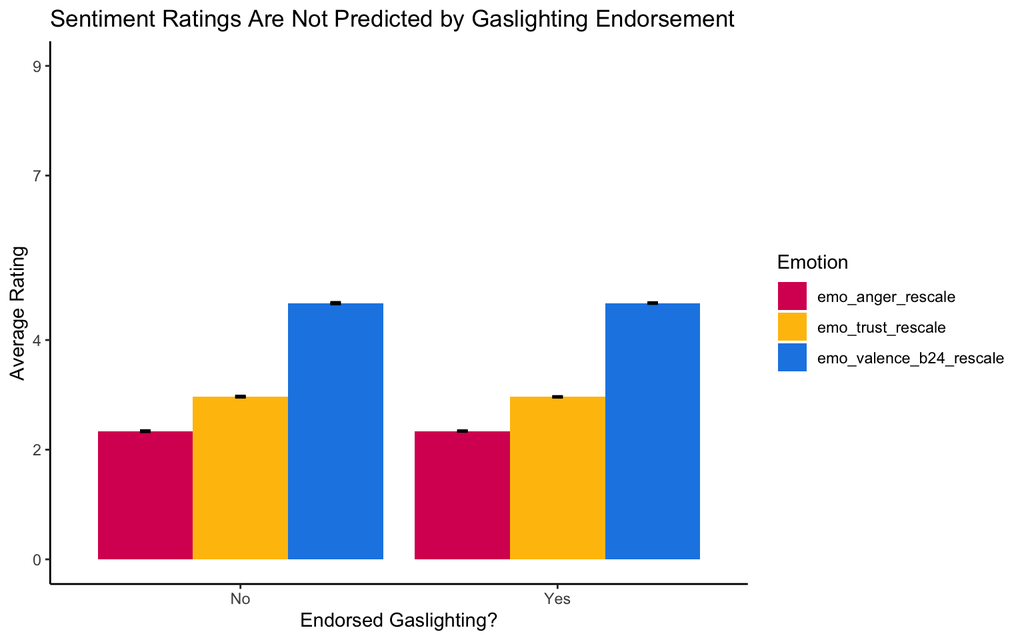

```r
#rearranging data for visualization
df_ggplot <- gaslight_analysis %>%
  dplyr::select(Ever_Gaslit, emo_anger_rescale, emo_valence_b24_rescale, emo_trust_rescale) %>% # selecting which columns to keep
  pivot_longer(cols = starts_with("emo"), names_to = "emotion", values_to = "rating") #pairing each column with its value vertically.

#bar plot of emotion
ggplot(df_ggplot, aes(x = Ever_Gaslit, y = rating, fill = emotion)) + #specifying variables for each axis
  geom_bar(position = "dodge", stat = "summary") + #specifying statistical analysis for bar graph (defaults to mean/sd)
  geom_errorbar(stat="summary",position=position_dodge(.9), width=0.1, size=.8) + #creating an error bar
  scale_fill_manual(values = c('emo_anger_rescale' = '#D81B60', 'emo_valence_b24_rescale' = '#1E88E5', 'emo_trust_rescale' = '#FFC107')) + #specifying what color represents each variable
  #scale_x_discrete(labels=c('Anger', 'Intensity', 'Trust', 'Valence')) + #creating clearer names for each variable
  scale_y_continuous(limits=c(0,9), breaks=c(0, 2, 4, 7, 9)) + #specifying y-axis limits
  labs (title = 'Sentiment Ratings Are Not Predicted by Gaslighting Endorsement',
        x = 'Endorsed Gaslighting?',
        y = 'Average Rating',
        fill = 'Emotion') +#creating labels for each part of the graph
  theme_classic()
```

# Results

It was hypothesized that individuals who endorsed gaslighting tell stories that are significantly higher in anger and negative valence, and lower on trust compared to individuals who don’t endorse gaslighting. Surprisingly, there was no significant difference in anger, valence, or trust between those who endorsed having been gaslit and those who have not.This was simultaneously the easiest linear model i’ve ever run and the most upsetting as there was literally almost NOT VISABLE DIFFERENCE between the groups. I’ve run the stats Jaime!!! They differ only by the 3rd decimal point. WHAT DOES IT MEAN???? LIVED EXPERIENCE MEANS NOTHING!!!